# Week 5 - Code Along Lab

Hannah Brady

11/8/2020

# Penguins size comparisons

Installed a bunch of packages in the console.

## Part 1. T-tests

Do we have enough evidence to think these are drawn from populations with separate means?

Mass comparison: male & female chinstrap penguins

In console: >View(penguins)

Explore data first

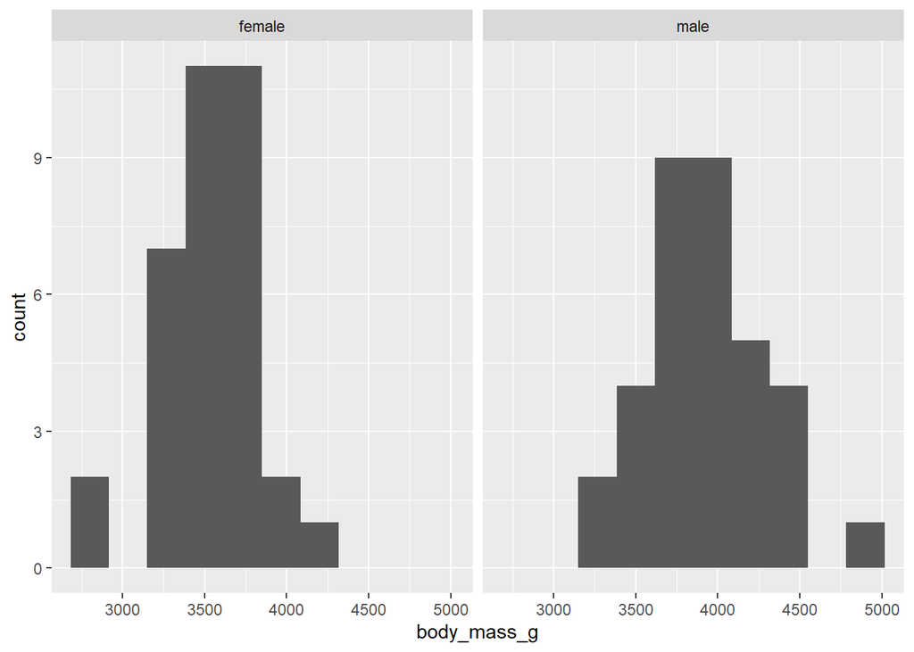

```r
chinstraps <- penguins %>%
  filter(species == "Chinstrap")

## Histograms

ggplot(data = chinstraps, aes(x = body_mass_g)) +
  geom_histogram(bins = 10) +
  facet_wrap(~sex)
```

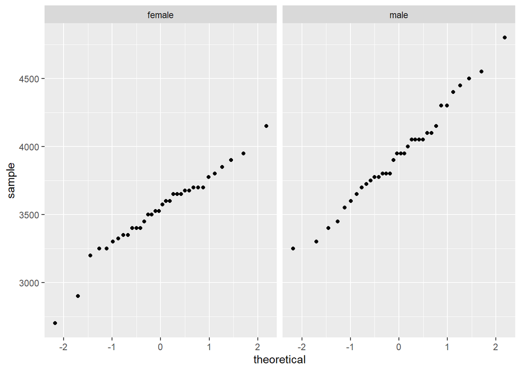

```r
# Interpretation:
# Somewhat bell-shaped, means mean is an appropriate central tendency to evaluate.
# Somewhat symmetric so relatively normal distribution
# Male central tendency seems higher than female.

## QQ plot

ggplot(data = chinstraps, aes(sample = body_mass_g)) +
  geom_qq()+
  facet_wrap(~sex)
```

```r
# A QQ plot plots the sample against a theoretically normally distributed sample, that's why linear = normally distributed
# Ran together before facet wrap and they looked normal already. But want to explore within groups so facet wrap.
# These are as close to normally distributed as you can hope real world data gets.

## Get descriptive statistics

chinstraps %>%
  group_by(sex) %>%
  summarise(
    mean_mass = mean(body_mass_g),
    median_mass = median(body_mass_g),
    sd_mass = sd(body_mass_g),
    sample_size = n()
  )
```

```
## # A tibble: 2 x 5
##   sex    mean_mass median_mass sd_mass sample_size
##   <fct>      <dbl>       <dbl>   <dbl>       <int>
## 1 female     3527.        3550    285.          34
## 2 male       3939.        3950    362.          34
```

```r
# Table not stored but output in RMD knitted file
# Means a bit different, median similar (normality tells us this would be the case)
# Same sample size, similar std devs.
# More important than the p-value!
```

Get vectors of body_mass_g for female and male chinstrap penguins separately.

```r
chinstraps_f <- chinstraps %>%
  filter(sex == "female") %>%
  pull(body_mass_g)

chinstraps_m <- chinstraps %>%
  filter(sex == "male") %>%
  pull(body_mass_g)
```

### T-tests, a couple different ways

1. Is there a significant difference in body mass between make and female chinstrap penguins.

This is a two-sided question. Not is one larger than the other, but in both directions.

```r
chinstrap_ttest <- t.test(chinstraps_f, chinstraps_m)
chinstrap_ttest
```

```
##
##  Welch Two Sample t-test
##
## data:  chinstraps_f and chinstraps_m
## t = -5.2077, df = 62.575, p-value = 2.264e-06
## alternative hypothesis: true difference in means is not equal to 0
## 95 percent confidence interval:
##  -569.7903 -253.7391
## sample estimates:
## mean of x mean of y
##  3527.206  3938.971
```

```r
cohen.d(chinstraps_f, chinstraps_m)
```

```
##
## Cohen's d
##
## d estimate: -1.263061 (large)
## 95 percent confidence interval:
##      lower      upper
## -1.7933879 -0.7327341
```

t value is how different from zero the means are, df is “degrees of freedom” dependent on sample size.

p-value is tiny! Suficient evidence to reject null hypothesis that two samples drawn from populations with same mean. We conclude that there is a signficant difference between male and female body mass. But need to discuss actual difference. Also effect size!

Magnitude of effect size is -1.26. This is large. Means large diff between groups’ means.

Broom function: see the key downloaded from Gauchospace to get outputs from t-test in a nice data frame so you can call the results easily as you type up results.

Are male chinstrap penguins significantly larger (body mass) than female chinstrap penguins?

This is a one-sided question. “What are the chances I would get means this different and larger?”

```r
t.test(chinstraps_m, chinstraps_f, alternative = "greater")
```

```
##
##  Welch Two Sample t-test
##
## data:  chinstraps_m and chinstraps_f
## t = 5.2077, df = 62.575, p-value = 1.132e-06
## alternative hypothesis: true difference in means is greater than 0
## 95 percent confidence interval:
##  279.7552      Inf
## sample estimates:
## mean of x mean of y
##  3938.971  3527.206
```

```r
# Is male mass greater than female? So put male then female then greater.
```

## One-way ANOVA

Single factor to compare three or more samples

## 1. Table of counts by penguin species and sex

```r
penguin_counts <- penguins %>%
  count(species, sex)

penguin_counts
```

```
## # A tibble: 8 x 3
##   species   sex        n
##   <fct>     <fct>  <int>
## 1 Adelie    female    73
## 2 Adelie    male      73
## 3 Adelie    <NA>       6
## 4 Chinstrap female    34
## 5 Chinstrap male      34
## 6 Gentoo    female    58
## 7 Gentoo    male      61
## 8 Gentoo    <NA>       5
```

```r
# More than 30 in each sample size so we know means should probably be normally distributed but still have to do exploratory data analysis and visualization
```

Create a subset of only female penguins

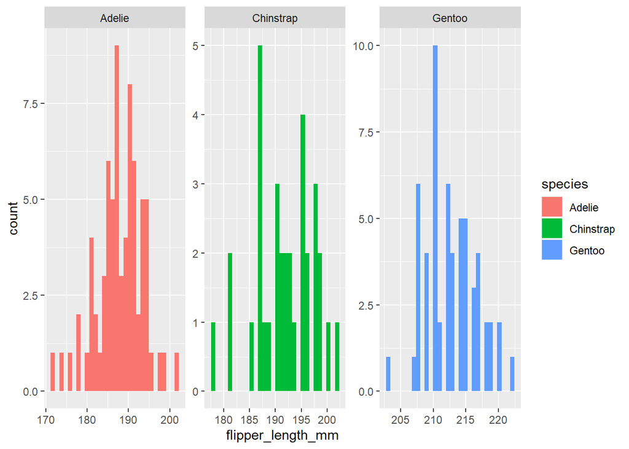

```r
penguin_f <- penguins %>%
  filter(sex == "female")

ggplot(data = penguin_f, aes(x = flipper_length_mm))+
  geom_histogram(aes(fill=species)) +
  facet_wrap(~species, scales = "free")
```

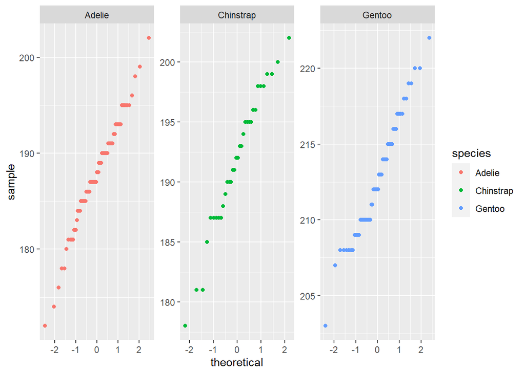

```r
# Facet wrap defaults to the same x and y axis but if you don't care about directly comparing everything, can add the scales free argument so that you can look at distributions of each group closer.

ggplot(data = penguin_f, aes(sample = flipper_length_mm))+
  geom_qq(aes(color=species)) +
  facet_wrap(~species, scales = "free")
```

```r
# qq is point graph so you use "color" instead of "fill"
```

Histogram is overall symmetric and bell shaped. Pretty close to normally distributed. QQ plot is very linear. Feel confident that it is normally distributed.

### Summary statistics

Starting from penguins_f, create a summary table that groups by species and returns the following:

- mean of flipper length
- sd ""
- sample size
- variance ‘var’
- standard error = sd / sqrt(n)

```r
penguin_f_summary <- penguin_f %>%
  group_by(species) %>%
  summarise(
    mean_length = mean(flipper_length_mm),
    sd_length = sd(flipper_length_mm),
    sample_size = n(),
    var_length = var(flipper_length_mm),
    std_err = sd(flipper_length_mm)/sqrt(n())
  )
# If largest variance is less than 4x smallest variance, we are close enough to use ANOVA. Here largest variance is only about 2x greater so we are within guidelines to run ANOVA but we need to run Levene's test for variance too.
# Note Levene's test has same pitfall of hypothesis testing that super large sample sizes almost always yield significant difference.

leveneTest(flipper_length_mm ~ species, data = penguin_f)
```

```
## Levene's Test for Homogeneity of Variance (center = median)
##        Df F value  Pr(>F)
## group   2  2.9012 0.05782 .
##       162
## ---
## Signif. codes:  0 '***' 0.001 '**' 0.01 '*' 0.05 '.' 0.1 ' ' 1
```

```r
# Variance in flipper length as a function of species, and then where to find data
```

Levene Test shows p-value greater than 0.05 so we retain null hypothesis that variances are equal/close enough to run ANOVA.

### Beeswarm plot with mean +/- 1 sd

Good visualization for showing stats with density

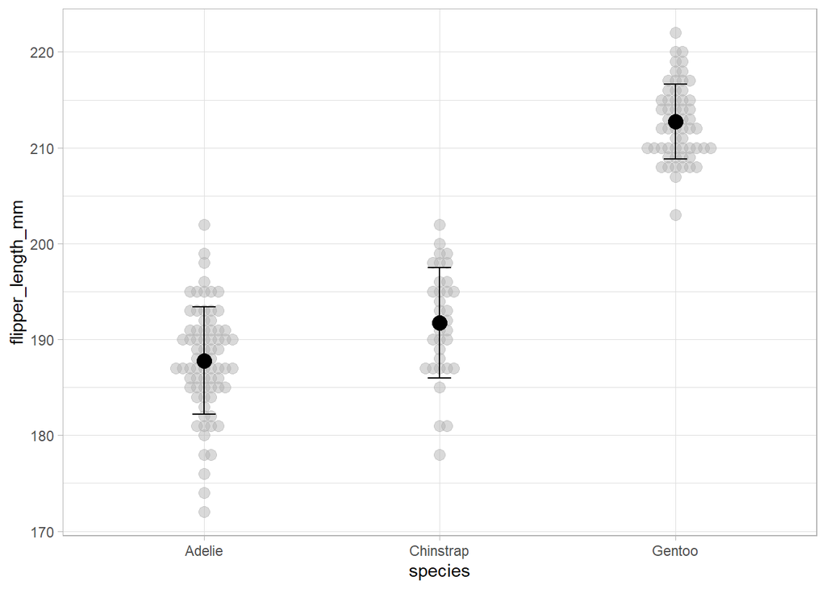

```r
ggplot() +
  geom_beeswarm(data = penguin_f,
                aes(x = species, y = flipper_length_mm),
                color = "gray70",
                size = 3,
                alpha = 0.5) +
  geom_point(data = penguin_f_summary, aes(x = species, y = mean_length),
             size = 4) +
  geom_errorbar(data = penguin_f_summary,
                aes(x = species,
                    ymax = mean_length + sd_length,
                    ymin = mean_length - sd_length),
                width = 0.1)+
  theme_light()
```

```r
# Alpha is transparency
# Most recent line sits on top of the previous lines
```

### One-way ANOVA

Uneven sample sizes usually means you want to use a type 3 ANOVA

```r
penguin_aov <- aov(flipper_length_mm ~ species, data = penguin_f)
summary(penguin_aov)
```

```
##              Df Sum Sq Mean Sq F value Pr(>F)
## species       2  21416   10708   411.8 <2e-16 ***
## Residuals   162   4213      26
## ---
## Signif. codes:  0 '***' 0.001 '**' 0.01 '*' 0.05 '.' 0.1 ' ' 1
```

```r
# Do a post-hoc test to do pairwise comparisons

TukeyHSD(penguin_aov)
```

```
##   Tukey multiple comparisons of means
##     95% family-wise confidence level
##
## Fit: aov(formula = flipper_length_mm ~ species, data = penguin_f)
##
## $species
##                       diff       lwr       upr     p adj
## Chinstrap-Adelie  3.940774  1.436275  6.445272 0.0007922
## Gentoo-Adelie    24.912376 22.790647 27.034105 0.0000000
## Gentoo-Chinstrap 20.971602 18.366227 23.576977 0.0000000
```

Huge F value, very large difference between groups compared to variance within groups. See this in the p-value: negligibly small. Reject null hypothesis that means for all of these groups are the same.

Tukey test shows that all groups have p-value below 0.05 so all pairwise combinations show significant difference.

Unbalanced design: Do this type 3/orthogonal ANOVA

Type III Anova with the car package: lm = linear model

```r
penguin_lm <- lm(flipper_length_mm ~ species, data = penguin_f)
penguin_aov_t3 <- Anova(penguin_lm, type = "III")
penguin_aov_t3
```

```
## Anova Table (Type III tests)
##
## Response: flipper_length_mm
##              Sum Sq  Df  F value    Pr(>F)
## (Intercept) 2574475   1 99005.28 < 2.2e-16 ***
## species       21416   2   411.79 < 2.2e-16 ***
## Residuals      4213 162
## ---
## Signif. codes:  0 '***' 0.001 '**' 0.01 '*' 0.05 '.' 0.1 ' ' 1
```

Note that unless they are egregiously unbalanced you will get very close outcomes to the other type of ANOVA. Perfecetly balanced design would you give you the same outcomes for Type I, II, and III.